# Oppgave 5: Rødvinskvalitet (kjemi) Anne Selseng & Kaia Rognaldsen

```python
import pandas as pd
from pprint import pprint
import matplotlib.pylab as plt
```

# Les av fila og undersøk dataene

```python
vin = pd.read_csv("vin12.csv")
```

Bruker funksjonen head() til å se på de første 5 radene med data

```python
pprint(vin.head())
```

```
   fixed acidity  volatile acidity  citric acid  residual sugar  chlorides  \
0            7.4              0.70         0.00             1.9      0.076
1            7.8              0.88         0.00             2.6      0.098
2            7.8              0.76         0.04             2.3      0.092
3           11.2              0.28         0.56             1.9      0.075
4            7.4              0.70         0.00             1.9      0.076

   free sulfur dioxide  total sulfur dioxide  density    pH  sulphates  \
0                 11.0                  34.0   0.9978  3.51       0.56
1                 25.0                  67.0   0.9968  3.20       0.68
2                 15.0                  54.0   0.9970  3.26       0.65
3                 17.0                  60.0   0.9980  3.16       0.58
4                 11.0                  34.0   0.9978  3.51       0.56

   alcohol  quality
0      9.4        5
1      9.8        5
2      9.8        5
3      9.8        6
4      9.4        5
```

Funksjonen .describe() viser statistikk om hvert faktor

```python
vin.describe()
```

|  | fixed acidity | volatile acidity | citric acid | residual sugar | chlorides | free sulfur dioxide | total sulfur dioxide | density | pH | sulphates | alcohol | quality |
| --- | --- | --- | --- | --- | --- | --- | --- | --- | --- | --- | --- | --- |
| count | 1599.000000 | 1599.000000 | 1599.000000 | 1599.000000 | 1599.000000 | 1599.000000 | 1599.000000 | 1599.000000 | 1599.000000 | 1599.000000 | 1599.000000 | 1599.000000 |
| mean | 8.319637 | 0.527821 | 0.270976 | 2.538806 | 0.087467 | 15.874922 | 46.467792 | 0.996747 | 3.311113 | 0.658149 | 10.422983 | 5.636023 |
| std | 1.741096 | 0.179060 | 0.194801 | 1.409928 | 0.047065 | 10.460157 | 32.895324 | 0.001887 | 0.154386 | 0.169507 | 1.065668 | 0.807569 |
| min | 4.600000 | 0.120000 | 0.000000 | 0.900000 | 0.012000 | 1.000000 | 6.000000 | 0.990070 | 2.740000 | 0.330000 | 8.400000 | 3.000000 |
| 25% | 7.100000 | 0.390000 | 0.090000 | 1.900000 | 0.070000 | 7.000000 | 22.000000 | 0.995600 | 3.210000 | 0.550000 | 9.500000 | 5.000000 |
| 50% | 7.900000 | 0.520000 | 0.260000 | 2.200000 | 0.079000 | 14.000000 | 38.000000 | 0.996750 | 3.310000 | 0.620000 | 10.200000 | 6.000000 |
| 75% | 9.200000 | 0.640000 | 0.420000 | 2.600000 | 0.090000 | 21.000000 | 62.000000 | 0.997835 | 3.400000 | 0.730000 | 11.100000 | 6.000000 |
| max | 15.900000 | 1.580000 | 1.000000 | 15.500000 | 0.611000 | 72.000000 | 289.000000 | 1.003690 | 4.010000 | 2.000000 | 14.900000 | 8.000000 |

Sjekker antall rader med data og hvilken datatype hver faktor har

```python
vin.info()
```

```
<class 'pandas.core.frame.DataFrame'>
RangeIndex: 1599 entries, 0 to 1598
Data columns (total 12 columns):
fixed acidity           1599 non-null float64
volatile acidity        1599 non-null float64
citric acid             1599 non-null float64
residual sugar          1599 non-null float64
chlorides               1599 non-null float64
free sulfur dioxide     1599 non-null float64
total sulfur dioxide    1599 non-null float64
density                 1599 non-null float64
pH                      1599 non-null float64
sulphates               1599 non-null float64
alcohol                 1599 non-null float64
quality                 1599 non-null int64
dtypes: float64(11), int64(1)
memory usage: 150.0 KB
```

# Finn gjennomsnitt med standardavvik av de ulike verdiene og lag en tabell med disse statistiske dataene.

Bruker .loc til å hente ut enkelte rader fra describe()

```python
vin.describe().loc[['mean','std']]
```

|  | fixed acidity | volatile acidity | citric acid | residual sugar | chlorides | free sulfur dioxide | total sulfur dioxide | density | pH | sulphates | alcohol | quality |
| --- | --- | --- | --- | --- | --- | --- | --- | --- | --- | --- | --- | --- |
| mean | 8.319637 | 0.527821 | 0.270976 | 2.538806 | 0.087467 | 15.874922 | 46.467792 | 0.996747 | 3.311113 | 0.658149 | 10.422983 | 5.636023 |
| std | 1.741096 | 0.179060 | 0.194801 | 1.409928 | 0.047065 | 10.460157 | 32.895324 | 0.001887 | 0.154386 | 0.169507 | 1.065668 | 0.807569 |

# Hvilken funksjon har svoveldioksid og sulfater i vin?

Svoveldioksid (SO2) brukes for å hindre at vin oksiderer og for å hindre vekst av gjær og bakterier. Faktorer som påvirker mengden svoveldioksid er typen vin, hygiene, produksjonsmetode og druekvalitet. Sulfitter er et viktig konserveringsmiddel som forhindrer syrring av vinen og forsterker rødfargen i vinen.

De fleste vinprodusenter tilsetter en liten del svoveldioksid når druene blir knust før pressing for å unngå faren for oksidering og for å ta knekken på uønskede bakterier. Når du tilsetter sulfitter, tar du ofte også knekken på de svakeste gjærsoppene. Sulfitt er konserveringmidler og virker antioksyderende.

```python
vin.describe()
```

|  | fixed acidity | volatile acidity | citric acid | residual sugar | chlorides | free sulfur dioxide | total sulfur dioxide | density | pH | sulphates | alcohol | quality |
| --- | --- | --- | --- | --- | --- | --- | --- | --- | --- | --- | --- | --- |
| count | 1599.000000 | 1599.000000 | 1599.000000 | 1599.000000 | 1599.000000 | 1599.000000 | 1599.000000 | 1599.000000 | 1599.000000 | 1599.000000 | 1599.000000 | 1599.000000 |
| mean | 8.319637 | 0.527821 | 0.270976 | 2.538806 | 0.087467 | 15.874922 | 46.467792 | 0.996747 | 3.311113 | 0.658149 | 10.422983 | 5.636023 |
| std | 1.741096 | 0.179060 | 0.194801 | 1.409928 | 0.047065 | 10.460157 | 32.895324 | 0.001887 | 0.154386 | 0.169507 | 1.065668 | 0.807569 |
| min | 4.600000 | 0.120000 | 0.000000 | 0.900000 | 0.012000 | 1.000000 | 6.000000 | 0.990070 | 2.740000 | 0.330000 | 8.400000 | 3.000000 |
| 25% | 7.100000 | 0.390000 | 0.090000 | 1.900000 | 0.070000 | 7.000000 | 22.000000 | 0.995600 | 3.210000 | 0.550000 | 9.500000 | 5.000000 |
| 50% | 7.900000 | 0.520000 | 0.260000 | 2.200000 | 0.079000 | 14.000000 | 38.000000 | 0.996750 | 3.310000 | 0.620000 | 10.200000 | 6.000000 |
| 75% | 9.200000 | 0.640000 | 0.420000 | 2.600000 | 0.090000 | 21.000000 | 62.000000 | 0.997835 | 3.400000 | 0.730000 | 11.100000 | 6.000000 |
| max | 15.900000 | 1.580000 | 1.000000 | 15.500000 | 0.611000 | 72.000000 | 289.000000 | 1.003690 | 4.010000 | 2.000000 | 14.900000 | 8.000000 |

# Plott ulike data mot hverandre

Korrelasjon er et numerisk mål på om to datasett varierer i takt. Som kan hjelpe meg å se hvilke faktorer som henger sammen, og derfor lettere å vite hvilke faktorer/data å plotte mot hverandre. For her kan vi se om to faktorer har liten sammenheng(tall nærme 0.0), eller stor sammenheng(tall nærmere 1 eller -1). Funksjonen .corr() regner ut dette for oss

```python
vin.corr()
```

|  | fixed acidity | volatile acidity | citric acid | residual sugar | chlorides | free sulfur dioxide | total sulfur dioxide | density | pH | sulphates | alcohol | quality |
| --- | --- | --- | --- | --- | --- | --- | --- | --- | --- | --- | --- | --- |
| fixed acidity | 1.000000 | -0.256131 | 0.671703 | 0.114777 | 0.093705 | -0.153794 | -0.113181 | 0.668047 | -0.682978 | 0.183006 | -0.061668 | 0.124052 |
| volatile acidity | -0.256131 | 1.000000 | -0.552496 | 0.001918 | 0.061298 | -0.010504 | 0.076470 | 0.022026 | 0.234937 | -0.260987 | -0.202288 | -0.390558 |
| citric acid | 0.671703 | -0.552496 | 1.000000 | 0.143577 | 0.203823 | -0.060978 | 0.035533 | 0.364947 | -0.541904 | 0.312770 | 0.109903 | 0.226373 |
| residual sugar | 0.114777 | 0.001918 | 0.143577 | 1.000000 | 0.055610 | 0.187049 | 0.203028 | 0.355283 | -0.085652 | 0.005527 | 0.042075 | 0.013732 |
| chlorides | 0.093705 | 0.061298 | 0.203823 | 0.055610 | 1.000000 | 0.005562 | 0.047400 | 0.200632 | -0.265026 | 0.371260 | -0.221141 | -0.128907 |
| free sulfur dioxide | -0.153794 | -0.010504 | -0.060978 | 0.187049 | 0.005562 | 1.000000 | 0.667666 | -0.021946 | 0.070377 | 0.051658 | -0.069408 | -0.050656 |
| total sulfur dioxide | -0.113181 | 0.076470 | 0.035533 | 0.203028 | 0.047400 | 0.667666 | 1.000000 | 0.071269 | -0.066495 | 0.042947 | -0.205654 | -0.185100 |
| density | 0.668047 | 0.022026 | 0.364947 | 0.355283 | 0.200632 | -0.021946 | 0.071269 | 1.000000 | -0.341699 | 0.148506 | -0.496180 | -0.174919 |
| pH | -0.682978 | 0.234937 | -0.541904 | -0.085652 | -0.265026 | 0.070377 | -0.066495 | -0.341699 | 1.000000 | -0.196648 | 0.205633 | -0.057731 |
| sulphates | 0.183006 | -0.260987 | 0.312770 | 0.005527 | 0.371260 | 0.051658 | 0.042947 | 0.148506 | -0.196648 | 1.000000 | 0.093595 | 0.251397 |
| alcohol | -0.061668 | -0.202288 | 0.109903 | 0.042075 | -0.221141 | -0.069408 | -0.205654 | -0.496180 | 0.205633 | 0.093595 | 1.000000 | 0.476166 |
| quality | 0.124052 | -0.390558 | 0.226373 | 0.013732 | -0.128907 | -0.050656 | -0.185100 | -0.174919 | -0.057731 | 0.251397 | 0.476166 | 1.000000 |

## Nå plotter jeg faktorer som har liten sammenheng, og noen mer stor sammenheng. Man kan se sammnhengen om det er et tydelig trend.

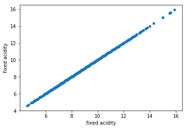

```python
vin.plot(kind='scatter', x='fixed acidity', y='fixed acidity')
```

Her kan du se et eksempel på 100% korrelasjon, altså stor sammenheng. Noe som ikke er så rart når man plotter en datakilde mot seg selv. Da blir det en helt rett kurve. Hvor Korrelasjonkoeffisienten er 1.

```python
vin.corr().loc[['chlorides', 'quality']]
```

|  | fixed acidity | volatile acidity | citric acid | residual sugar | chlorides | free sulfur dioxide | total sulfur dioxide | density | pH | sulphates | alcohol | quality |
| --- | --- | --- | --- | --- | --- | --- | --- | --- | --- | --- | --- | --- |
| chlorides | 0.093705 | 0.061298 | 0.203823 | 0.055610 | 1.000000 | 0.005562 | 0.0474 | 0.200632 | -0.265026 | 0.371260 | -0.221141 | -0.128907 |
| quality | 0.124052 | -0.390558 | 0.226373 | 0.013732 | -0.128907 | -0.050656 | -0.1851 | -0.174919 | -0.057731 | 0.251397 | 0.476166 | 1.000000 |

```python
def hentTall (vin,rad,kolonne):
    corr = vin[rad].corr(vin[kolonne])
    return corr

hentTall(vin,'fixed acidity','fixed acidity')
```

```
1.0
```

#### Fixed acidity vs density

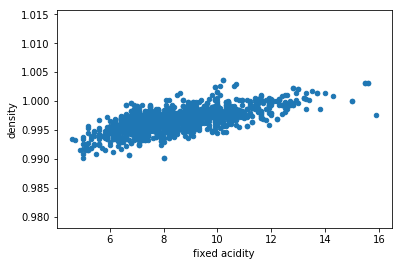

```python
vin.plot(kind='scatter', x='fixed acidity', y='density')
```

```python
hentTall(vin,'fixed acidity','density')
```

```
0.6680472921189737
```

Her ser du også et annet eksempel på stor korrelasjon mellom to datakilder. Her ser vi sammenhengen mellom fixed acidity og density. Hvor korrelasjonskoeffienten er 0.668

#### Chlorides vs free sulfur dioxide

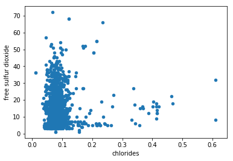

```python
vin.plot(kind='scatter', x='chlorides', y='free sulfur dioxide')
```

```python
hentTall(vin,'chlorides','free sulfur dioxide')
```

```
0.005562147004781119
```

Her ser vi lite korrelasjon mellom faktorene chlorides (klorider) og free sulfur dioxide (svoveldioksid tilsatt i vinen). Korrelasjonkoeffisienten er 0.0055

#### Fixed acidity vs citric acid

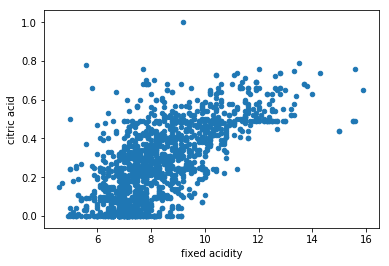

```python
vin.plot(kind='scatter', x='fixed acidity', y='citric acid')
```

```python
hentTall(vin,'fixed acidity','citric acid')
```

```
0.6717034347641059
```

#### Free sulfur dioxide vs total sulfur dioxide

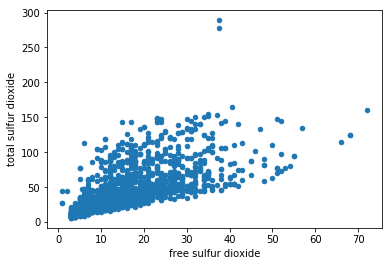

```python
vin.plot(kind='scatter', x='free sulfur dioxide', y='total sulfur dioxide')
```

```python
hentTall(vin,'free sulfur dioxide','total sulfur dioxide')
```

```
0.6676664504810215
```

Her ser vi også en stor sammenheng mellom free sulfur dioxide og total sulfur dioxide (svoveldioksid tilsatt i vinen), altså en stor korrelasjon. Dette er naturlig fordi begge omhandler svoveldioksid. Korrelasjonkoeffisienten er 0.667

#### Quality vs chlorides

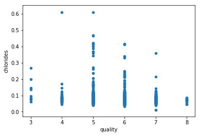

```python
vin.plot(kind='scatter', x='quality', y='chlorides')
```

```python
hentTall(vin,'quality','chlorides')
```

```
-0.12890655993005276
```

Her ser vi at det er en liten sammenheng mellom klorider og kvalitet, altså liten korrelasjon. Korrelasjonskoeffisient er -0.128907

#### Volatile acidity vs residual sugar

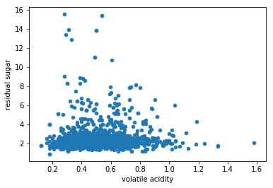

```python
vin.plot(kind='scatter', x='volatile acidity', y='residual sugar')
```

```python
hentTall(vin,'volatile acidity','residual sugar')
```

```
0.0019178819627907358
```

Her kan du se at det er lite sammenheng mellom volatile acidity (Mengden syre og flyktig syre) og residual sugar (Mengden sukker etter endt fermentering av vinen). Hvor korrelasjonskoeffisient er 0.001918

#### Fixed acidity vs pH

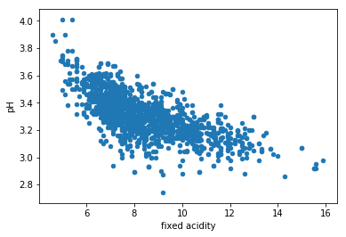

```python
vin.plot(kind='scatter', x='fixed acidity', y='pH')
```

```python
hentTall(vin,'pH','fixed acidity')
```

```
-0.6829781945685316
```

Her ser vi en negativ korrelasjon mellom Ph og fixed acidity (Mengden syre og flyktig syre (gasser)), hvor korrelasjonskoeffisient er -0.6829.

#### Ph vs citric acid

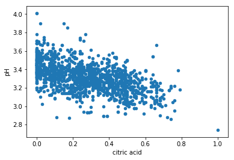

```python
vin.plot(kind='scatter', x='citric acid', y='pH')
```

```python
hentTall(vin,'citric acid','pH')
```

```
-0.5419041447395097
```

Her ser vi også et annet eksempel på negativ korrelasjon mellom citric acid (sitronsyre) og ph. Hvor korrelasjonskoeffisient er -0.54

# Finn ut hvilke faktorer som korrelerer med rødvinskvaliteten.

```python
vin.corr()['quality']
```

```
fixed acidity           0.124052
volatile acidity       -0.390558
citric acid             0.226373
residual sugar          0.013732
chlorides              -0.128907
free sulfur dioxide    -0.050656
total sulfur dioxide   -0.185100
density                -0.174919
pH                     -0.057731
sulphates               0.251397
alcohol                 0.476166
quality                 1.000000
Name: quality, dtype: float64
```

Jo lenger unna 0 tallene er, jo mer henger de sammen. Altså at de korrelerer. Her ser vi at det alcohol og volatile acidity som er lengst unna 0. Så det betyr at de variablene er de som påvirker kvaliteten på vinen mest.

Alcohol har en positiv korrelasjon mot quality, så de stiger sammen. Altså jo mer alkohol jo bedre kvalitet, og motsatt. Mens den flyktig syren har en negativ korrelasjon mot quality. Så når kvaliteten stiger, synker volatile acidity. Jo bedre kvalitet, jo mindre volatile acidity.

#### Quality vs Volatile acidity

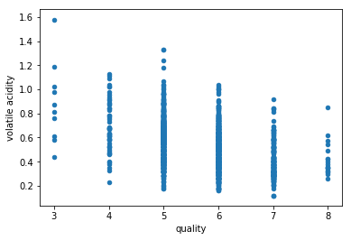

```python
vin.plot(kind='scatter', x='quality', y='volatile acidity')
```

```python
plt.show()
```

```python
hentTall(vin,'quality','volatile acidity')
```

```
-0.390557780264007
```

Generelt høy volatile acidity gir generelt lavere kvalitet (syre og flyktig syre (gasser)). Korrelasjonskoeffisienten er -0.39

#### Quality vs Alcohol

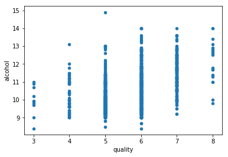

```python
vin.plot(kind='scatter', x='quality', y='alcohol')
```

```python
hentTall(vin,'quality','alcohol')
```

```
0.4761663240011359
```

Her ser du at alkoholnivået er korrelert med kvalitet, altså jo bedre kvalitet jo mer alkohol. Korrelasjonskoeffisienten er 0.476

#### Quality vs Sulphates

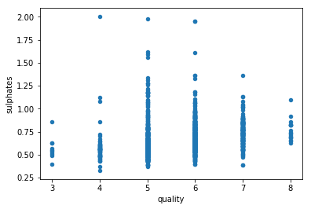

```python
vin.plot(kind='scatter', x='quality', y='sulphates')
```

```python
hentTall(vin,'quality','sulphates')
```

```
0.2513970790692613
```

Her er korrelasjonskoeffisienten 0.251. Sammenhengen mellom quality og sulphates er ikke så stor, du kan se at det er en litt lavere verdi av sulphates i de verste vinene, enn de beste.

#### Quality vs Residual sugar

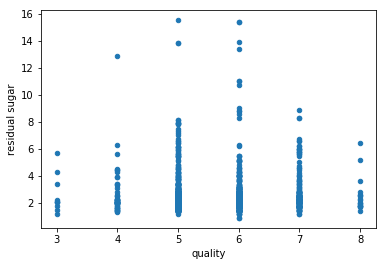

```python
vin.plot(kind='scatter', x='quality', y='residual sugar')
```

```python
hentTall(vin,'quality','residual sugar')
```

```
0.013731637340066305
```

Her vi en liten korrelasjon mellom residual sugar og quality. De vinene med høy residual sugar har middels kvalitet, men lav residual sugar har både høy og lav kvalitet. Korrelasjonskoeffisienten er 0.013

#### Quality vs pH

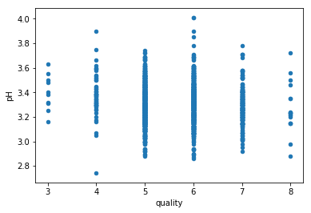

```python
vin.plot(kind='scatter', x='quality', y='pH')
```

```python
hentTall(vin,'quality','pH')
```

```
-0.057731391205382156
```

## Korrelasjon og Kausalitet

Korrelasjon er kun et numerisk mål på om to datasett varierer i takt. Kausalitet er tilfeldige sammenhenger, og det er en årsakssammenheng mellom årsak og virkning. Korrelasjoner kan hjelpe med å avklare kausalitet. For når man prøver å fastslå kauslitetet, så undersøker man korrelasjoner.

Kvaliteten som vi har jobbet med nå er subjektiv, altså at det er forskjellig fra person til person. De andre faktorene/kolonenne er objektiv, man regner det ut med målinger. Så korrelasjonen avhenger av person som avgjør kvaliteten, siden vi har forskjellige smaker.

# Rødvinskvalitet rapport

I dette prosjektet skal vi knytte programmet vårt til større databaser med informasjon og trekke informasjon ut fra disse databasene. Deretter skal programmet vårt tolke informasjon og behandle data. Vi valgte en oppgave om å rødvinskvalitet, hvor vi fikk utdelt et datasett med ulike faktorer i vin som utgjør kvaliteten.

Vi startet med å tolke datasettet hvor vi brukte ulike innebygde funksjoner for å få bedre oversikt over datasettet vi ble gitt. Da vi plottet de ulike dataene opp mot hverandre, valgte vi å finne korrelasjonskoeffisienten til de ulike faktorene, for å se hvilke faktorer vi burde sette opp mot hverandre. Korrelasjonskoeffisienten forteller oss hvor mye faktorene henger hverandre, altså sammenhengen mellom de. Hvis faktorene har liten sammenheng er koeffisienten et tall nærme 0.0, mens hvis det er stor sammenheng er det et tall nærmere 1 eller -1.

Ut i fra disse korrelasjonskoeffisientene valgte vi å plotte faktorer med både stor og liten sammenheng. For å vise forskjellen mellom stor og liten korrelasjon. Vi ser et tydelig mønster på de forskjellige grafene på om det er stor eller liten sammenheng. Ut i fra grafene kan vi se at der punktene danner et mønster eller en vekstkurve. Punktene som er samlet tett sammen viser at det er en sammenheng mellom faktorene. I motsetning til der punktene er spredt rundt og ikke danner et mønster hvor det er liten sammenheng mellom de to faktorene.

Når vi skulle finne ut av hvilke faktorer som korrelerer med vinkvaliteten fant vi korrelasjonskoeffisientene mellom ‘quality’ og de andre faktorene. Som sagt, jo lenger unna 0 tallene er, jo mer henger de sammen, altså at de korrelerer. Vi fant ut at det er ‘alcohol’ og ‘volatile acidity’ som er lengst unna 0. Dette betyr at det er de variablene som påvirker kvaliteten på vinen mest. ‘Alcohol’ har en positiv korrelasjon mot ‘quality’, så de stiger sammen. Altså jo mer alkohol jo bedre kvalitet, og motsatt. Mens ved flyktig syren har en negativ korrelasjon mot quality. Så når kvaliteten stiger, synker volatile acidity. Jo bedre kvalitet, jo mindre volatile acidity.

Volatile acidity, citric acid, sulphates og alcohol er de faktorene som påvirker kvaliteten mest. Vi ser at kvaliteten øker når chlorides, free sulfur dioxide, total sulfur dioxide, total sulfur dioxide, density, pH og volatile acidity synker. Dette fordi de har en negativ korrelasjon.

I dette forsøket har vi gått nærmere inn på hva som påvirker vinen, og de ulike faktorene som vinen inneholder. Noe vi må huske er at kvaliteten som vi har jobbet med nå er subjektiv, altså at det er forskjellig fra person til person. De andre faktorene er objektiv, man regner det ut med målinger. Så korrelasjonen avhenger av person som avgjør kvaliteten, siden vi har forskjellige smaker. Noe vi må ha i bakhodet mens vi tolker resultatene. Det er ikke nødvendigvis alltid slik at det er alkoholen som gjør en vin til en god vin.